# Tidyverse crash course @ iDiv

Emilio Berti

23/09/2022

# Today’s program

- General intro (10 minutes).
- Packages and hands-on sessions.
- Datasets: *kalenji.csv* and *garmin.csv*.

# Today’s program

- General intro (10 minutes).
- Packages and hands-on sessions.
- Datasets: *kalenji.csv* and *garmin.csv*.

[figure not shown]

Sampling equipment

# Today’s program

- General intro (10 minutes).
- Packages and hands-on sessions.
- Datasets: *kalenji.csv* and *garmin.csv*.

[figure not shown]

Sampling equipment

1. Introduce packages, functionalities, and data wrangling.
2. Transform tables into what you want.
3. Work with more than one table: merge them, compare them, etc.

# What is the tidyverse?

[figure not shown]

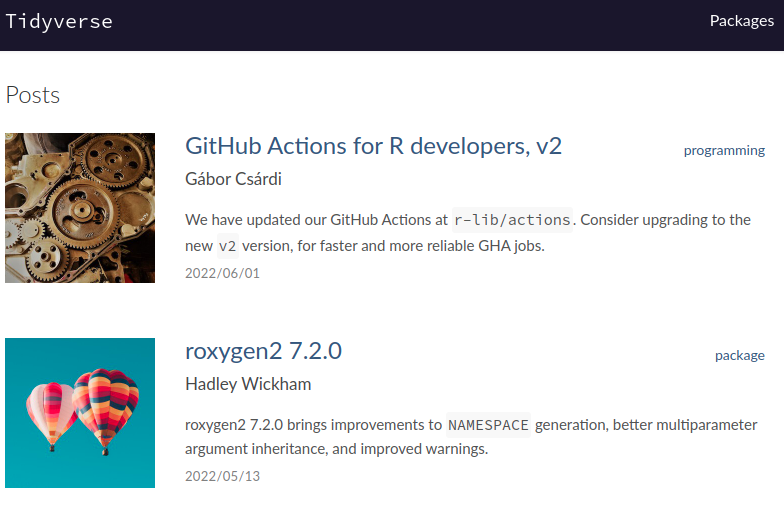

$\,$

# Where to find these slides

https://emilio-berti.github.io/Teaching.html

# Why the tidyverse? Because it’s for lazy people.

```r
d
```

```
##          date   km    time
## 1  10/27/2021  6.0 0:34:28
## 2  10/27/2021  6.0 0:33:24
## 3  10/31/2021 10.3 0:59:19
## 4   11/6/2021  8.7 0:54:00
## 5  11/13/2021  8.7 0:49:00
## 6  11/17/2021  4.6 0:25:28
## 7  11/21/2021 10.4 1:02:00
## 8  11/30/2021  6.0 0:34:08
## 9  11/30/2021  6.0 0:33:03
## 10  12/5/2021  6.2 0:35:00
## 11  12/9/2021  6.2 0:37:33
## 12 12/19/2021  6.2 0:35:22
## 13 12/22/2021  6.2 0:36:00
## 14 12/28/2021  6.2 0:35:00
```

[output cut: 37 more lines]

# Why the tidyverse? Because it’s for lazy people.

```r
as_tibble(d)
```

```
## # A tibble: 51 × 3
##    date          km time
##    <chr>      <dbl> <chr>
##  1 10/27/2021   6   0:34:28
##  2 10/27/2021   6   0:33:24
##  3 10/31/2021  10.3 0:59:19
##  4 11/6/2021    8.7 0:54:00
##  5 11/13/2021   8.7 0:49:00
##  6 11/17/2021   4.6 0:25:28
##  7 11/21/2021  10.4 1:02:00
##  8 11/30/2021   6   0:34:08
##  9 11/30/2021   6   0:33:03
## 10 12/5/2021    6.2 0:35:00
## # … with 41 more rows
```

# Why the tidyverse? Because it makes the code more readable.

```r
sub_d <- d[d$km > 4, ]
sub_d <- sub_d[sub_d$km < 6, ]
summary(sub_d$km)
```

```
##    Min. 1st Qu.  Median    Mean 3rd Qu.    Max.
##     4.6     4.6     4.6     4.6     4.6     4.6
```

# Why the tidyverse? Because it makes the code more readable.

```r
d %>%
  as_tibble() %>%
  filter(km > 4, km < 6) %>%
  pull(km) %>%
  summary()
```

```
##    Min. 1st Qu.  Median    Mean 3rd Qu.    Max.
##     4.6     4.6     4.6     4.6     4.6     4.6
```

# Why the tidyverse? Because you will learn SQL without knowing it.

```r
d %>%
  as_tibble() %>%
  filter(km > 4, km < 6) %>%
  pull(km) %>%
  summary()
```

```
##    Min. 1st Qu.  Median    Mean 3rd Qu.    Max.
##     4.6     4.6     4.6     4.6     4.6     4.6
```

In SQL:

```r
SELECT
km
FROM
d
WHERE km > 4 AND km < 6;
```

# Basic ideas of tidyverse

1. Tables are the fundamental units of your analysis.
2. Tidy data: forces good practices for data science.
3. Complex table manipulations can be evaluated on the fly.
4. Table manipulations can be organized in modules.
5. Modules can be pipelined: `%>%`.

# Basic ideas of tidyverse

Total distance and best time for each route - on the fly.

```r
read_csv("kalenji.csv", show_col_types = FALSE) %>%
  transmute(
    time = minute(time) + hour(time) * 60, #total minutes
    Distance = round(km) #round distance
  ) %>%
  group_by(Distance) %>% #evalute by group
  summarize(
    `Total distance` = sum(Distance),
    `Fastest time` = min(time)
  ) %>%
  arrange(desc(`Total distance`)) %>%
  knitr::kable()
```

| Distance | Total distance | Fastest time |
| --- | --- | --- |
| 6 | 246 | 28 |
| 9 | 54 | 45 |
| 10 | 20 | 59 |
| 8 | 8 | 43 |
| 5 | 5 | 25 |

# tibble

# tibble - goal

Goal: table data keeping only good features of *data.frame*.

Pros:

- cleaner
- better problem detection
- no implicit modifications
- better print method
- can handle complex names: e.g., `variable with spaces and / $ .`

Cons:

- Some packages still requires a *data.frame* object.

# tibble - what it looks like

```r
d
```

```
##          date   km    time
## 1  10/27/2021  6.0 0:34:28
## 2  10/27/2021  6.0 0:33:24
## 3  10/31/2021 10.3 0:59:19
## 4   11/6/2021  8.7 0:54:00
## 5  11/13/2021  8.7 0:49:00
## 6  11/17/2021  4.6 0:25:28
## 7  11/21/2021 10.4 1:02:00
## 8  11/30/2021  6.0 0:34:08
## 9  11/30/2021  6.0 0:33:03
## 10  12/5/2021  6.2 0:35:00
## 11  12/9/2021  6.2 0:37:33
## 12 12/19/2021  6.2 0:35:22
## 13 12/22/2021  6.2 0:36:00
## 14 12/28/2021  6.2 0:35:00
```

[output cut: 37 more lines]

# tibble - from data.frames

```r
as_tibble(d)
```

```
## # A tibble: 51 × 3
##    date          km time
##    <chr>      <dbl> <chr>
##  1 10/27/2021   6   0:34:28
##  2 10/27/2021   6   0:33:24
##  3 10/31/2021  10.3 0:59:19
##  4 11/6/2021    8.7 0:54:00
##  5 11/13/2021   8.7 0:49:00
##  6 11/17/2021   4.6 0:25:28
##  7 11/21/2021  10.4 1:02:00
##  8 11/30/2021   6   0:34:08
##  9 11/30/2021   6   0:33:03
## 10 12/5/2021    6.2 0:35:00
## # … with 41 more rows
```

# tibble - from matrices

```r
mat <- matrix(1:100, 50, 2)
colnames(mat) <- c("x", "y")
as_tibble(mat)
```

```
## # A tibble: 50 × 2
##        x     y
##    <int> <int>
##  1     1    51
##  2     2    52
##  3     3    53
##  4     4    54
##  5     5    55
##  6     6    56
##  7     7    57
##  8     8    58
##  9     9    59
## 10    10    60
## # … with 40 more rows
```

# tibble - from lists

```r
l <- list(x = 1:10, y = 1:10)
as_tibble(l)
```

```
## # A tibble: 10 × 2
##        x     y
##    <int> <int>
##  1     1     1
##  2     2     2
##  3     3     3
##  4     4     4
##  5     5     5
##  6     6     6
##  7     7     7
##  8     8     8
##  9     9     9
## 10    10    10
```

# tibble - create new data

```r
tibble(x = LETTERS[1:10], y = 1:10)
```

```
## # A tibble: 10 × 2
##    x         y
##    <chr> <int>
##  1 A         1
##  2 B         2
##  3 C         3
##  4 D         4
##  5 E         5
##  6 F         6
##  7 G         7
##  8 H         8
##  9 I         9
## 10 J        10
```

# tibble - compatibility issues with packages

```r
moveHMM::prepData(as_tibble(l))
```

```
## <error/vctrs_error_subscript_oob>
## Error in `vectbl_as_col_location()`:
## ! Can't subset columns past the end.
## ℹ Location 2 doesn't exist.
## ℹ There is only 1 column.
## ---
## Backtrace:
##  1. base::tryCatch(moveHMM::prepData(as_tibble(l)), error = function(e) print(e))
##  5. moveHMM::prepData(as_tibble(l))
##  7. tibble:::`[.tbl_df`(x, i)
##  8. tibble:::vectbl_as_col_location(j, length(x), names(x), j_arg = j_arg, assign = FALSE)
```

# tibble - compatibility issues: as.data.frame()

```r
moveHMM::prepData(as.data.frame(l))
```

```
##         ID     step        angle  x  y
## 1  Animal1 156.8744           NA  1  1
## 2  Animal1 156.8276 0.0004610422  2  2
## 3  Animal1 156.7574 0.0006155637  3  3
## 4  Animal1 156.6639 0.0007703128  4  4
## 5  Animal1 156.5472 0.0009253809  5  5
## 6  Animal1 156.4073 0.0010808595  6  6
## 7  Animal1 156.2444 0.0012368401  7  7
## 8  Animal1 156.0586 0.0013934143  8  8
## 9  Animal1 155.8500 0.0015506736  9  9
## 10 Animal1       NA           NA 10 10
```

# tibble - printing options

```r
options(tibble.print_max = 4, tibble.print_min = 4)
as_tibble(l)
```

```
## # A tibble: 10 × 2
##       x     y
##   <int> <int>
## 1     1     1
## 2     2     2
## 3     3     3
## 4     4     4
## # … with 6 more rows
```

# tibble - practical 1 - problem

1. Create two vectors *x* and *y* with 10 random numbers (e.g. `runif()`).
2. Create a tibble with columns *x* and *y*.

# tibble - practical 1 - solution

1. Create two vectors *x* and *y* with 10 random numbers (e.g. `runif()`).
2. Create a tibble with columns *x* and *y*.

```r
x <- runif(10)
y <- runif(10)
tibble(x, y)
```

```
## # A tibble: 10 × 2
##        x      y
##    <dbl>  <dbl>
## 1 0.771  0.905
## 2 0.220  0.745
## 3 0.394  0.0169
## 4 0.0518 0.622
## # … with 6 more rows
```

# tibble - practical 2 - problem

1. Create a vector *x* with 10 random numbers (e.g. `runif()`).
2. Create a vector *y* with 5 random numbers (e.g. `runif()`).
3. Create a data.frame with columns *x* and *y*.
4. Create a tibble with columns *x* and *y*.

# tibble - practical 2 - solution

1. Create a vector *x* with 10 random numbers (e.g. `runif()`).
2. Create a vector *y* with 5 random numbers (e.g. `runif()`).
3. Create a data.frame with columns *x* and *y*.

```r
x <- runif(10)
y <- runif(5)
data.frame(x, y)
```

```
##            x         y
## 1  0.8002872 0.7593188
## 2  0.3531292 0.4823047
## 3  0.5712468 0.2036041
## 4  0.2484056 0.9589408
## 5  0.1329216 0.7326067
## 6  0.6193830 0.7593188
## 7  0.3570391 0.4823047
## 8  0.3006154 0.2036041
## 9  0.7815725 0.9589408
## 10 0.5639128 0.7326067
```

# tibble - practical 2 - solution

1. Create a vector *x* with 10 random numbers (e.g. `runif()`).
2. Create a vector *y* with 5 random numbers (e.g. `runif()`).
3. Create a data.frame with columns *x* and *y*.
4. Create a tibble with columns *x* and *y*.

```r
x <- runif(10)
y <- runif(5)
tibble(x, y)
```

```
## <error/tibble_error_incompatible_size>
## Error:
## ! Tibble columns must have compatible sizes.
## • Size 10: Existing data.
## • Size 5: Column at position 2.
## ℹ Only values of size one are recycled.
## ---
## Backtrace:
##  1. base::tryCatch(...)
##  5. tibble::tibble(x, y)
##  6. tibble:::tibble_quos(xs, .rows, .name_repair)
##  7. tibble:::vectbl_recycle_rows(res, first_size, j, given_col_names[[j]])
```

# tibble - practical 2 - solution

```r
x <- runif(10)
tibble(x, y = 0)
```

```
## # A tibble: 10 × 2
##       x     y
##   <dbl> <dbl>
## 1 0.258     0
## 2 0.810     0
## 3 0.435     0
## 4 0.979     0
## # … with 6 more rows
```

# readr

# readr - goal

Goal: load tabular data from delimited files (comma-separated).

Pros:

- fast and friendly
- support many types of data
- informative table summary and problem reports

Cons:

- syntax can be sometimes frustrating

# readr - read data

```r
d <- read.csv("kalenji.csv")
str(d)
```

```
## 'data.frame':    51 obs. of  3 variables:
##  $ date: chr  "10/27/2021" "10/27/2021" "10/31/2021" "11/6/2021" ...
##  $ km  : num  6 6 10.3 8.7 8.7 4.6 10.4 6 6 6.2 ...
##  $ time: chr  "0:34:28" "0:33:24" "0:59:19" "0:54:00" ...
```

# readr - read data

```r
d <- read_csv("kalenji.csv")
```

# readr - read data - suppress messages

```r
d <- read_csv("kalenji.csv", show_col_types = FALSE) #suppress summary
```

# readr - returns a tibble

*readr* loads directly a tibble:

```r
read_csv("kalenji.csv", show_col_types = FALSE)
```

```
## # A tibble: 51 × 3
##   date          km time
##   <chr>      <dbl> <time>
## 1 10/27/2021   6   34'28"
## 2 10/27/2021   6   33'24"
## 3 10/31/2021  10.3 59'19"
## 4 11/6/2021    8.7 54'00"
## # … with 47 more rows
```

# readr - good column guessing

*readr* is smart:

```r
d <- read_csv("kalenji.csv", show_col_types = FALSE)
d$time[2] - d$time[1]
```

```
## Time difference of -64 secs
```

# readr - read general text delimited file

```r
d <- read_delim("kalenji.txt", #general delimited file
                delim = ";",
                show_col_types = FALSE)
```

# readr - write to file

*readr* can, of course, write to files.

```r
write_csv(d, "copy-of-kalenji.csv")
```

# readr - practical 1 - problem

1. Create a tibble with 10 random *x* and 10 random *y*.
2. Save it as *random-numbers.csv*.
3. Save it as *random-numbers.txt* using `;` as separator.
4. Load them both.

# readr - practical 1 - solution

1. Create a tibble with 10 random *x* and 10 random *y*.
2. Save it as *random-numbers.csv*.
3. Save it as *random-numbers.txt* using `;` as separator.
4. Load them both.

```r
d <- tibble(x = runif(10), y = runif(10))
# write files
write_csv(d, "random-numbers.csv")
write_delim(d, "random-numbers.txt", delim = ";")
# read files
d_csv <- read_csv("random-numbers.csv", show_col_types = FALSE)
d_semi <- read_delim("random-numbers.csv", show_col_types = FALSE, delim = ";")
```

# readr - really faster?

For a 24 Mb table with 29,000 rows:

|  | test | replications | elapsed | relative |
| --- | --- | --- | --- | --- |
| 2 | base | 10 | 4.942 | 5.291 |
| 3 | data.table | 10 | 0.934 | 1.000 |
| 1 | readr | 10 | 3.457 | 3.701 |

# magrittr - pipe

Before going deeper: *magrittr* pipe **%>%**.

*command_1* **PIPE** *command_2* **PIPE** *command_3*

PIPE = take output from left and pass it as input to right.

EXECUTE *command_1* AND PASS ITS OUPTUT TO *command_2* AND PASS ITS OUTPUT TO *command_3*.

`round(mean(abs(x))) = x %>% abs() %>% mean() %>% round()`

# magrittr - what’s a pipe?

Before going deeper: *magrittr* pipe **%>%**.

`command PIPE command PIPE command`

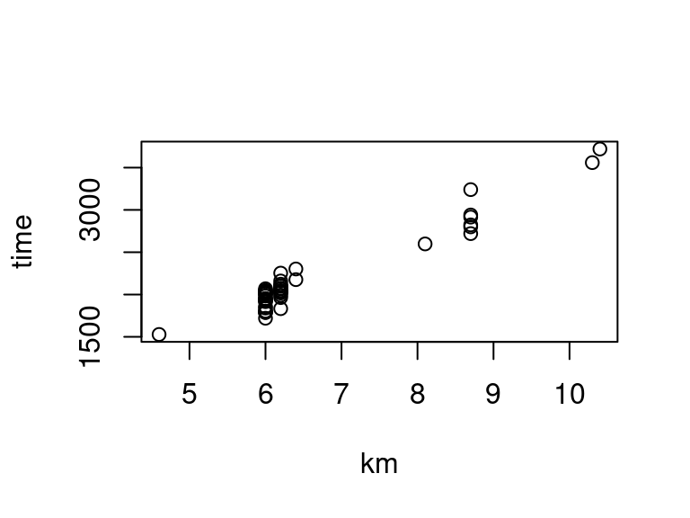

```r
d <- read_csv("kalenji.csv", show_col_types = FALSE)
d <- d[, c("km", "time")]
plot(d)
```

# magrittr - pipe your way to glory!

Before going deeper: *magrittr* pipe **%>%**.

`command PIPE command PIPE command`

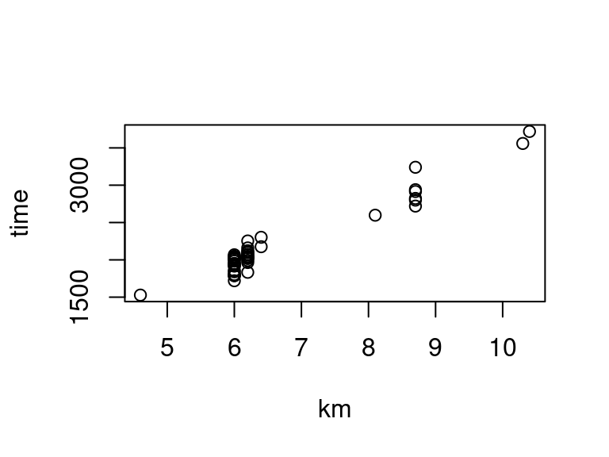

```r
#make sure input/output is of the correct type
read_csv("kalenji.csv", show_col_types = FALSE) %>% #output = tibble
  select(km, time) %>% #output = tibble
  plot() #output = figure
```

# magrittr - pipe practical 1 - problem

1. Create a tibble with *x*, *y* (`runif(10)`) and plot it without saving objects in the RAM.

# magrittr - pipe practical 1 - solution

1. Create a tibble with *x*, *y* (`runif(10)`) and plot it without saving objects in the RAM.

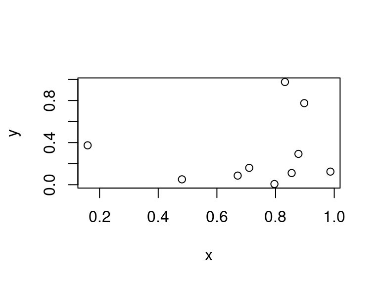

```r
tibble(x = runif(10), y = runif(10)) %>%
  plot()
```

# magrittr - pipe practical 2 - problem

1. Load *kalenji.csv* and plot it without saving objects in the RAM.

# magrittr - pipe practical 2 - solution

1. Load *kalenji.csv* and plot it without saving objects in the RAM.

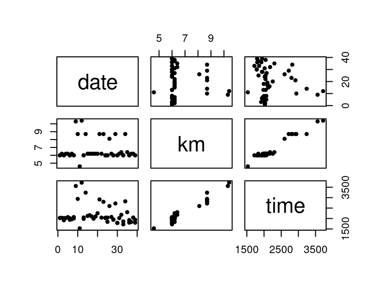

```r
read_csv("kalenji.csv", show_col_types = FALSE) %>% plot(pch = 20)
```

# dplyr

# dplyr - goal

Goal: Standardize data manipulation.

Pros:

- intuitive verbs: *select*, *filter*, etc.
- extremely versatile.
- compact and modular complex data manipulaitons.

Cons:

- more complex manipulations can be scaring.

# dplyr - lifecycle

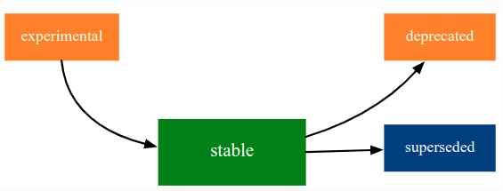

Life cycle of tidyverse functions

# dplyr - lifecycle in help()

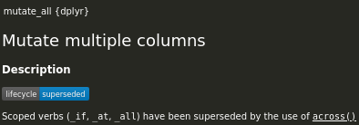

A superseded example

# dplyr - key verbs

Common verbs:

- `filter()`: retain rows conditionally.
- `select()`: select columns and drop the rest.
- `mutate()`: create a new column.
- `pull()`: extract one column as a vector.
- `summarize()`: summarize columns.
- `group_by()`: *groups* tables into *sub-tables*. Each groups is manipulated separately.
- `arrange()`: sort rows by values.
- `slice()`: select rows by ID, randomly, firsts, etc.
- `join()`**: join tables**.

# dplyr - filter()

`filter()` retains rows conditionally.

# dplyr - filter() - example

`filter()` retains rows conditionally.

```r
d %>% filter(km < 6)
```

```
## # A tibble: 1 × 2
##      km time
##   <dbl> <time>
## 1   4.6 25'28"
```

# dplyr - filter() - more examples

`filter()` retains rows conditionally.

```r
d %>% filter(km < 6)
d %>% filter(km == 6)
d %>% filter(km > 4, km < 8) #greater than 4 AND less than 8
d %>% filter(km < 4 | km > 8) #less than 4 OR greater than 8
```

# dplyr - filter() - practical - problem

1. Retain only observations with even number of km (`%% 2 == 0`).
2. Retain only observations between 5 and 7 km.

# dplyr - filter() - practical - solution

1. Retain only observations with even number of km (`%% 2 == 0`).

```r
d %>% filter(km %% 2 == 0)
```

```
## # A tibble: 24 × 2
##      km time
##   <dbl> <time>
## 1     6 34'28"
## 2     6 33'24"
## 3     6 34'08"
## 4     6 33'03"
## # … with 20 more rows
```

# dplyr - filter() - practical - solution

1. Retain only observations with even number of km (`%% 2 == 0`).
2. Retain only observations between 5 and 7 km.

```r
d %>% filter(km >= 5, km <= 7)
```

```
## # A tibble: 41 × 2
##      km time
##   <dbl> <time>
## 1     6 34'28"
## 2     6 33'24"
## 3     6 34'08"
## 4     6 33'03"
## # … with 37 more rows
```

# dplyr - select()

`select()` selects some columns and drops the rest.

# dplyr - select() - example

`select()` selects some columns and drops the rest.

```r
d %>% select(km) #d[, "km"]
```

```
## # A tibble: 51 × 1
##      km
##   <dbl>
## 1   6
## 2   6
## 3  10.3
## 4   8.7
## # … with 47 more rows
```

# dplyr - select() - also reversed

You can also *non*-select columns with -

```r
d %>% select(-km)
```

```
## # A tibble: 51 × 1
##   time
##   <time>
## 1 34'28"
## 2 33'24"
## 3 59'19"
## 4 54'00"
## # … with 47 more rows
```

# dplyr - tidyselect intermezzo

What if we want to select several columns conditionally?

```r
tidysel <- tibble(
  Outcome = runif(10, 2, 3),
  `Predictor 1` = runif(10, -1, 1),
  `Predictor 2` = runif(10, 10, 150),
  `First levels` = rep(c("A", "B"), 5),
  `Second levels` = rep(c("C", "D"), 5)
)
tidysel
```

```
## # A tibble: 10 × 5
##   Outcome `Predictor 1` `Predictor 2` `First levels` `Second levels`
##     <dbl>         <dbl>         <dbl> <chr>          <chr>
## 1    2.37         0.328          72.2 A              C
## 2    2.78        -0.619          87.7 B              D
## 3    2.12        -0.924         133.  A              C
## 4    2.66         0.282          64.6 B              D
## # … with 6 more rows
```

*tidyselect* allows this flexibility.

# dplyr - tidyselect intermezzo - select columns starting with “Pred”

```r
tidysel %>% select(starts_with("Pred"))
```

```
## # A tibble: 10 × 2
##   `Predictor 1` `Predictor 2`
##           <dbl>         <dbl>
## 1         0.328          72.2
## 2        -0.619          87.7
## 3        -0.924         133.
## 4         0.282          64.6
## # … with 6 more rows
```

# dplyr - tidyselect intermezzo - select columns containing “levels”

```r
tidysel %>% select(contains("levels"))
```

```
## # A tibble: 10 × 2
##   `First levels` `Second levels`
##   <chr>          <chr>
## 1 A              C
## 2 B              D
## 3 A              C
## 4 B              D
## # … with 6 more rows
```

# dplyr - tidyselect intermezzo - select only numeric columns

For this, we need to use also the `where` helper, which checks conditions on columns.

Conditions must return `TRUE` or `FALSE`, e.g. `is.numeric`.

```r
tidysel %>% select(where(is.numeric))
```

```
## # A tibble: 10 × 3
##   Outcome `Predictor 1` `Predictor 2`
##     <dbl>         <dbl>         <dbl>
## 1    2.37         0.328          72.2
## 2    2.78        -0.619          87.7
## 3    2.12        -0.924         133.
## 4    2.66         0.282          64.6
## # … with 6 more rows
```

# dplyr - tidyselect intermezzo - where

`where` is extremely useful for many verbs in *dplyr*. We will see more cases later.

You can already appreciate its simplicity, though:

```r
# in base R
pca <- prcomp(tidysel[, c("Outcome", "Predictor 1", "Predictor 2")])
```

```r
# in tidyverse
pca <- tidysel %>%
  select(where(is.numeric)) %>%
  prcomp()
```

*Application: PCAs on climate data*

# dplyr - tidyselect intermezzo - selection alternatives

In base R there are several way to do the same as:

```r
tidysel %>% select(where(is.numeric))
```

This is not safe:

```r
tidysel[, c(1, 2, 3)]
#what if the position of columns changes?
```

This is not scalable:

```r
tidysel[, c("Outcome", "Predictor 1", "Predictor 2")]
#what if you add a new numeric column?
```

The only safe and scalable way except the tidyverse one is:

```r
coltypes <- sapply(colnames(tidysel), \(x) class(tidysel[[x]]))
tidysel[, coltypes == "numeric"]
```

# 15 minutes break

[figure not shown]

Don’t drink soap.

# dplyr - mutate()

`mutate()` creates new columns (or modifies existing ones).

# dplyr - mutate() - example

`mutate()` creates new columns (or modifies existing ones).

```r
library(lubridate) #this will save you time
d <- read_csv("kalenji.csv", show_col_types = FALSE)
d <- d %>% mutate(Date = as_date(date, format = "%m/%d/%y"))
```

# dplyr - mutate() - compact it please.

```r
d <- read_csv("kalenji.csv", show_col_types = FALSE)
d <- d %>% mutate(Date = as_date(date, format = "%m/%d/%y"))
d
```

```
## # A tibble: 51 × 4
##   date          km time   Date
##   <chr>      <dbl> <time> <date>
## 1 10/27/2021   6   34'28" 2020-10-27
## 2 10/27/2021   6   33'24" 2020-10-27
## 3 10/31/2021  10.3 59'19" 2020-10-31
## 4 11/6/2021    8.7 54'00" 2020-11-06
## # … with 47 more rows
```

Can you compress this even more and make it more readable?

Do we need the old *date* column?

# dplyr - mutate() - compacted

```r
d <- read_csv("kalenji.csv", show_col_types = FALSE) %>%
  mutate(date = as_date(date, format = "%m/%d/%y"))
```

# dplyr - mutate() - practical - problem

1. Create three new columns (*month*, *week*, *day*) using *lubridate* `month()`, `week()`, and `day()`.

# dplyr - mutate() - practical - solution

1. Create three new columns (*month*, *week*, *day*) using *lubridate* `month()`, `week()`, and `day()`.

```r
d <- d %>%
  mutate(
    month = month(date, label = TRUE, abbr = FALSE),
    week = week(date),
    day = day(date)
  )
d
```

```
## # A tibble: 51 × 6
##   date          km time   month     week   day
##   <date>     <dbl> <time> <ord>    <dbl> <int>
## 1 2020-10-27   6   34'28" October     43    27
## 2 2020-10-27   6   33'24" October     43    27
## 3 2020-10-31  10.3 59'19" October     44    31
## 4 2020-11-06   8.7 54'00" November    45     6
## # … with 47 more rows
```

# dplyr - mutate() - tidyselect

`mutate()` can make use of *tidyselect*, but within the **across()** helper.

The syntax always looks like: mutate(**across(where(** *condition* **)**, fn**)**).

```r
tidysel %>% mutate(across(starts_with("Pred"), round, 1))
```

```
## # A tibble: 10 × 5
##   Outcome `Predictor 1` `Predictor 2` `First levels` `Second levels`
##     <dbl>         <dbl>         <dbl> <chr>          <chr>
## 1    2.37           0.3          72.2 A              C
## 2    2.78          -0.6          87.7 B              D
## 3    2.12          -0.9         133.  A              C
## 4    2.66           0.3          64.6 B              D
## # … with 6 more rows
```

```r
tidysel %>% mutate(across(where(is.character), tolower))
```

```
## # A tibble: 10 × 5
##   Outcome `Predictor 1` `Predictor 2` `First levels` `Second levels`
##     <dbl>         <dbl>         <dbl> <chr>          <chr>
## 1    2.37         0.328          72.2 a              c
## 2    2.78        -0.619          87.7 b              d
## 3    2.12        -0.924         133.  a              c
## 4    2.66         0.282          64.6 b              d
## # … with 6 more rows
```

# dplyr - pull()

`pull()` extracts one column as vector.

# dplyr - pull() - example

`pull()` extracts one column as vector.

```r
d %>% pull(km)
```

```
##  [1]  6.0  6.0 10.3  8.7  8.7  4.6 10.4  6.0  6.0  6.2  6.2  6.2  6.2  6.2  6.2
## [16]  6.2  6.0  6.0  6.2  6.0  6.0  6.2  6.0  6.0  6.2  6.0  6.0  6.2  6.0  6.0
## [31]  8.7  6.2  8.7  6.0  6.0  8.1  6.4  6.4  6.2  8.7  6.0  6.0  6.2  6.0  6.0
## [46]  8.7  6.0  6.0  6.2  6.0  6.0
```

# dplyr - pull() - practical - problem

1. Get the `table()` of *month* and sort it by count.

# dplyr - pull() - practical - solution

1. Get the `table()` of *month* and sort it by count.

```r
d %>%
  pull(month) %>%
  table() %>%
  sort()
```

```
## .
##       May      June      July    August September     April   October  November
##         0         0         0         0         0         3         3         6
##  December   January  February     March
##         6        10        11        12
```

# dplyr - summarize()

`summarize()` summarizes columns.

# dplyr - summarize() - example

`summarize()` summarizes columns.

```r
d %>% summarize(
  `shortest distance` = min(km),
  `average distance` = mean(km),
  `maximum distance` = max(km)
)
```

```
## # A tibble: 1 × 3
##   `shortest distance` `average distance` `maximum distance`
##                 <dbl>              <dbl>              <dbl>
## 1                 4.6               6.58               10.4
```

# dplyr - summarize() - practical 1 - problem

1. Summarize *Total km* as sum of all distances and *Total time* as sum of all times.

# dplyr - summarize() - practical 1 - solution

1. Summarize *Total km* as sum of all distances and *Total time* as sum of all times (as hours).

```r
d %>%
  summarize(
    `Total km` = sum(km),
    `Total time` = (time %>% sum() %>% as.numeric()) / 3600
  )
```

```
## # A tibble: 1 × 2
##   `Total km` `Total time`
##        <dbl>        <dbl>
## 1       335.         30.7
```

# dplyr - summarize() - tidyselect

```r
tidysel %>% summarize(
  across(contains("Pred"), #tidyselect
         list(min = min, max = max), #summary stats
         .names = "{col} : {fn}") #names of columns
)
```

```
## # A tibble: 1 × 4
##   `Predictor 1 : min` `Predictor 1 : max` `Predictor 2 : min` `Predictor 2 : m…`
##                 <dbl>               <dbl>               <dbl>              <dbl>
## 1              -0.924               0.679                24.2               150.
```

# dplyr - summarize() - practical 2 - problem

1. Summarize all numeric variables to get mean and median values.

# dplyr - summarize() - practical 2 - solution

1. Summarize all numeric variables to get mean and median values.

```r
d %>%
  summarize(across(where(is.numeric),
                   list(mean = mean, median = median),
                   .names = "{fn} of {col}"))
```

```
## # A tibble: 1 × 6
##   `mean of km` `median of km` `mean of week` `median of week` `mean of day`
##          <dbl>          <dbl>          <dbl>            <dbl>         <dbl>
## 1         6.58            6.2           19.6               11          17.1
## # … with 1 more variable: `median of day` <int>
```

# dplyr - group_by()

dplyr operations can also be performed on groups within tables by using `group_by()`.

For instance, the sum of all distances for the whole *kalenji* dataset is:

```r
d %>% summarize(`Total distance` = sum(km))
```

```
## # A tibble: 1 × 1
##   `Total distance`
##              <dbl>
## 1             335.
```

# dplyr - group_by() - example

To get the summary *sum* for each month separately, we just need to specify *month* as the grouping variable. dplyr would then perform the next operation on each group separately:

```r
d %>%
  group_by(month) %>%
  summarize(`Total distance` = sum(km))
```

```
## # A tibble: 7 × 2
##   month    `Total distance`
##   <ord>               <dbl>
## 1 January              60.8
## 2 February             73.9
## 3 March                78.6
## 4 April                18.2
## # … with 3 more rows
```

# dplyr - group_by() - practical 1 - problem

1. Count the number of observation in each month

# dplyr - group_by() - practical 1 - solution

1. Count the number of observation in each month

```r
d %>%
  group_by(month) %>%
  summarize(n = length(km))
```

```
## # A tibble: 7 × 2
##   month        n
##   <ord>    <int>
## 1 January     10
## 2 February    11
## 3 March       12
## 4 April        3
## # … with 3 more rows
```

# dplyr - group_by() - practical 1 - tally()

1. Count the number of observation in each month

```r
d %>%
  group_by(month) %>%
  tally()
```

```
## # A tibble: 7 × 2
##   month        n
##   <ord>    <int>
## 1 January     10
## 2 February    11
## 3 March       12
## 4 April        3
## # … with 3 more rows
```

# dplyr - group_by() - practical 2 - problem

1. Calculate the total distance per week within months

# dplyr - group_by() - practical 2 - solution

1. Calculate the total distance per week within months

```r
d %>%
  group_by(month, week) %>%
  summarize(`Total km` = sum(km)) %>%
  filter(week > 3) #simply to show you why week and month
```

```
## # A tibble: 24 × 3
## # Groups:   month [7]
##   month     week `Total km`
##   <ord>    <dbl>      <dbl>
## 1 January      4       18.2
## 2 January      5        6.2
## 3 February     5       12
## 4 February     6       18.2
## # … with 20 more rows
```

**The output is still grouped**.

# dplyr - group_by() - practical 2 - ungroup()

If you don’t need groups, `ungroup()` the table, or you may get unexpected results later on.

```r
d %>%
  group_by(month, week) %>%
  summarize(`Total km` = sum(km), .groups = "drop")
```

or

```r
d %>%
  group_by(month, week) %>%
  summarize(`Total km` = sum(km)) %>%
  ungroup()
```

# dplyr - group_by() - practical 2 - lifecycle?

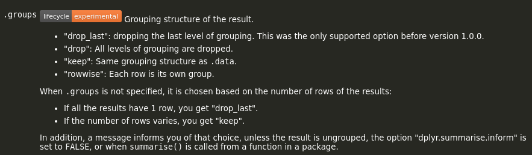

Always read the documentation

# Lunch break

[figure not shown]

We’ll be back at 1.

# dplyr - join()

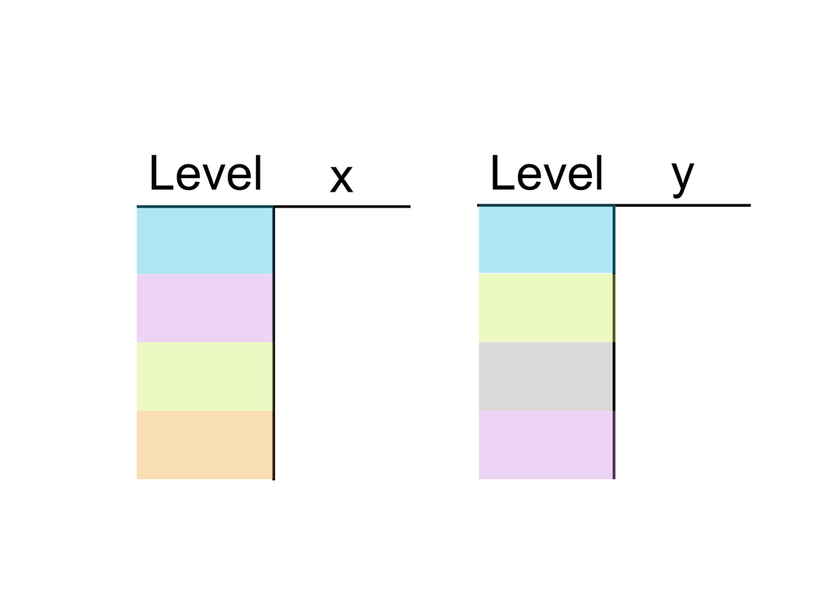

Two tables to join

$\,$

# dplyr - join()

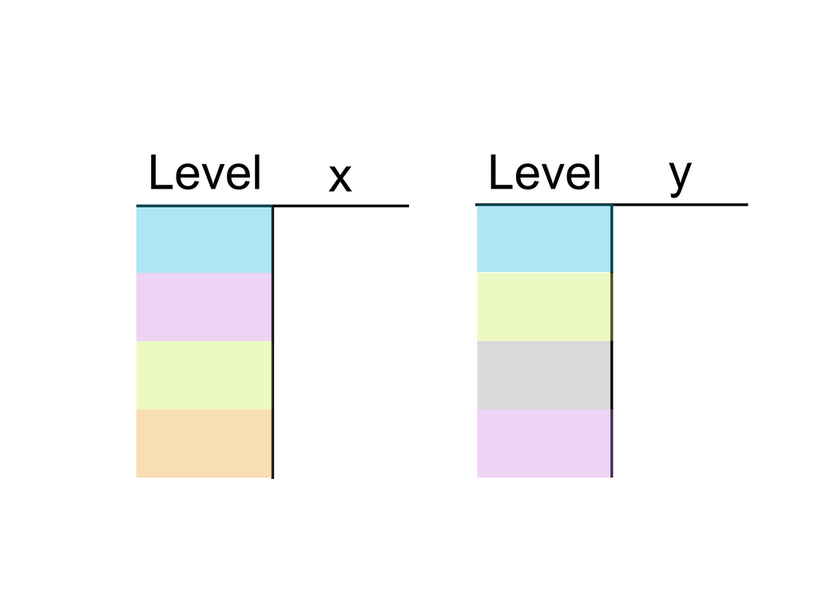

Two tables to join

$\longrightarrow$

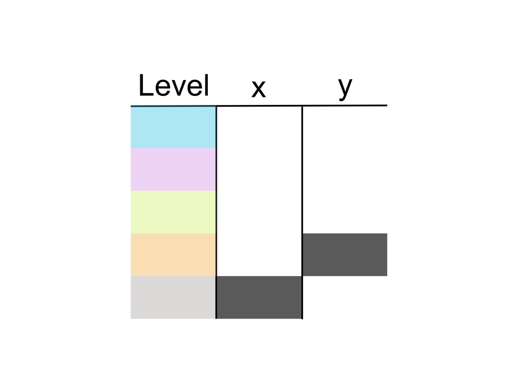

Joined table

# dplyr - join() - example

```r
left_table <- tibble(Group = LETTERS[1:3], x = rnorm(3))
right_table <- tibble(Group = LETTERS[2:4], y = rnorm(3))
```

```r
left_table
```

```
## # A tibble: 3 × 2
##   Group      x
##   <chr>  <dbl>
## 1 A     0.0453
## 2 B     0.586
## 3 C     0.770
```

```r
right_table
```

```
## # A tibble: 3 × 2
##   Group      y
##   <chr>  <dbl>
## 1 B      1.05
## 2 C     -0.852
## 3 D      1.11
```

# dplyr - join() - types

Output tables has:

1. `full_join(left_table, right_table)` - all levels
2. `inner_join(left_table, right_table)` - only levels in both
3. `left_join(left_table, right_table)` - only levels in *left_table*
4. `right_join(left_table, right_table)` - only levels in *right_table*

```r
left_table
```

```
## # A tibble: 3 × 2
##   Group      x
##   <chr>  <dbl>
## 1 A     0.0453
## 2 B     0.586
## 3 C     0.770
```

```r
right_table
```

```
## # A tibble: 3 × 2
##   Group      y
##   <chr>  <dbl>
## 1 B      1.05
## 2 C     -0.852
## 3 D      1.11
```

# dplyr - join() - full join

```r
left_table
```

```
## # A tibble: 3 × 2
##   Group      x
##   <chr>  <dbl>
## 1 A     0.0453
## 2 B     0.586
## 3 C     0.770
```

```r
right_table
```

```
## # A tibble: 3 × 2
##   Group      y
##   <chr>  <dbl>
## 1 B      1.05
## 2 C     -0.852
## 3 D      1.11
```

```r
full_join(left_table, right_table)
```

```
## # A tibble: 4 × 3
##   Group       x      y
##   <chr>   <dbl>  <dbl>
## 1 A      0.0453 NA
## 2 B      0.586   1.05
## 3 C      0.770  -0.852
## 4 D     NA       1.11
```

# dplyr - join() - inner join

```r
left_table
```

```
## # A tibble: 3 × 2
##   Group      x
##   <chr>  <dbl>
## 1 A     0.0453
## 2 B     0.586
## 3 C     0.770
```

```r
right_table
```

```
## # A tibble: 3 × 2
##   Group      y
##   <chr>  <dbl>
## 1 B      1.05
## 2 C     -0.852
## 3 D      1.11
```

```r
inner_join(left_table, right_table)
```

```
## # A tibble: 2 × 3
##   Group     x      y
##   <chr> <dbl>  <dbl>
## 1 B     0.586  1.05
## 2 C     0.770 -0.852
```

# dplyr - join() - left join

```r
left_table
```

```
## # A tibble: 3 × 2
##   Group      x
##   <chr>  <dbl>
## 1 A     0.0453
## 2 B     0.586
## 3 C     0.770
```

```r
right_table
```

```
## # A tibble: 3 × 2
##   Group      y
##   <chr>  <dbl>
## 1 B      1.05
## 2 C     -0.852
## 3 D      1.11
```

```r
left_join(left_table, right_table)
```

```
## # A tibble: 3 × 3
##   Group      x      y
##   <chr>  <dbl>  <dbl>
## 1 A     0.0453 NA
## 2 B     0.586   1.05
## 3 C     0.770  -0.852
```

# dplyr - join() - right join

```r
left_table
```

```
## # A tibble: 3 × 2
##   Group      x
##   <chr>  <dbl>
## 1 A     0.0453
## 2 B     0.586
## 3 C     0.770
```

```r
right_table
```

```
## # A tibble: 3 × 2
##   Group      y
##   <chr>  <dbl>
## 1 B      1.05
## 2 C     -0.852
## 3 D      1.11
```

```r
right_join(left_table, right_table)
```

```
## # A tibble: 3 × 3
##   Group      x      y
##   <chr>  <dbl>  <dbl>
## 1 B      0.586  1.05
## 2 C      0.770 -0.852
## 3 D     NA      1.11
```

# dplyr - join() - by?

Joining requires (at least) one *joining* variable. Avoid ambiguity: specify it.

```r
left_table %>% left_join(right_table, by = "Group")
```

```
## # A tibble: 3 × 3
##   Group      x      y
##   <chr>  <dbl>  <dbl>
## 1 A     0.0453 NA
## 2 B     0.586   1.05
## 3 C     0.770  -0.852
```

# dplyr - join() - by multiple variables

You can join by **multiple** variables.

```r
left_table <- tibble(`First level` = sample(LETTERS, 100, replace = TRUE),
                     `Second level` = sample(letters, 100, replace = TRUE),
                     x = rnorm(100))
right_table <- tibble(`First level` = sample(LETTERS, 100, replace = TRUE),
                      `Second level` = sample(letters, 100, replace = TRUE),
                      y = rnorm(100))
inner_join(left_table, right_table, by = c("First level", "Second level"))
```

```
## # A tibble: 16 × 4
##   `First level` `Second level`      x      y
##   <chr>         <chr>           <dbl>  <dbl>
## 1 U             s               1.08   0.697
## 2 K             m              -0.106 -0.182
## 3 J             y              -1.26  -0.588
## 4 F             x               0.411  1.03
## # … with 12 more rows
```

# dplyr - join() - by different names

Variables do not need to have the same name.

```r
left_table <- tibble(`First level` = sample(LETTERS, 100, replace = TRUE),
                     `Second level` = sample(letters, 100, replace = TRUE),
                     x = rnorm(100))
right_table <- tibble(`First group` = sample(LETTERS, 100, replace = TRUE),
                      `Second group` = sample(letters, 100, replace = TRUE),
                      y = rnorm(100))
inner_join(left_table, right_table,
           by = c("First level" = "First group",
                  "Second level" = "Second group"))
```

```
## # A tibble: 26 × 4
##   `First level` `Second level`      x      y
##   <chr>         <chr>           <dbl>  <dbl>
## 1 L             h              -0.764  0.856
## 2 D             j              -0.447 -0.149
## 3 F             f               1.58  -0.118
## 4 T             u              -0.684  1.25
## # … with 22 more rows
```

# dplyr - join() - practical - problem

I have the name of the routes.

```r
routes <- read_csv("routes.csv", show_col_types = FALSE)
routes
```

```
## # A tibble: 6 × 2
##   distance `route name`
##      <dbl> <chr>
## 1      4.6 stadium
## 2      6   work
## 3      6.4 first bridge
## 4      8.7 second bridge
## # … with 2 more rows
```

1. Assign the route names to the *kalenji.csv* table.
2. Count the number of km I ran for each route.
3. Arrange them in decreasing order.
4. Rename missing routes as: “no name”.

# dplyr - join() - practical - solution

1. Assign the route names to the *kalenji.csv* table.
2. Count the number of km I ran for each route.
3. Arrange them in decreasing order.
4. Rename missing routes as: “no name”.

```r
d %>%
  left_join(routes, by = c("km" = "distance")) %>%
  group_by(`route name`) %>%
  summarise(`Total km` = sum(km)) %>%
  arrange(desc(`Total km`)) %>%
  mutate(`route name` = ifelse(is.na(`route name`), "no name", `route name`))
```

```
## # A tibble: 6 × 2
##   `route name`  `Total km`
##   <chr>              <dbl>
## 1 work               144
## 2 no name            101.
## 3 second bridge       52.2
## 4 train lake          20.7
## # … with 2 more rows
```

# The *garmin.csv* dataset

# garmin dataset

```r
garmin <- read_csv("garmin.csv", show_col_types = FALSE)
garmin
```

```
## # A tibble: 74 × 41
##   `Activity Type` Date                Favorite Title    Distance Calories Time
##   <chr>           <dttm>              <lgl>    <chr>       <dbl>    <dbl> <time>
## 1 Running         2022-09-08 08:19:19 FALSE    Stara Z…     5.35      484 36'08"
## 2 Running         2022-09-04 10:48:08 FALSE    Leipzig…     8.41      698 47'50"
## 3 Running         2022-09-02 07:04:01 FALSE    Leipzig…     6.76      524 39'15"
## 4 Running         2022-09-01 16:42:50 FALSE    Leipzig…     5.7       457 31'20"
## # … with 70 more rows, and 34 more variables: `Avg HR` <dbl>, `Max HR` <dbl>,
## #   `Avg Run Cadence...10` <dbl>, `Max Run Cadence...11` <dbl>,
## #   `Avg Pace` <chr>, `Best Pace` <chr>, `Total Ascent` <chr>,
## #   `Total Descent` <chr>, `Avg Stride Length` <dbl>,
## #   `Avg Vertical Ratio` <dbl>, `Avg Vertical Oscillation` <dbl>,
## #   `Avg Ground Contact Time` <dbl>, `Avg Run Cadence...20` <dbl>,
## #   `Max Run Cadence...21` <dbl>, `Training Stress Score®` <dbl>, …
```

We are interested only in *Activity Type = Running* and columns: *Date*, *Distance*, *Time*, *Avg HR*.

# garmin dataset - practical 1 - problem

1. Filter only *Running* entries.
2. Select only relevant columns: *Date*, *Distance*, *Time*, *Avg HR*.
3. Create new column *Speed = Distance / Time (km/h)*.
4. Plot them using `pairs()`.

# garmin dataset - practical 1 - solution

1. Filter only *Running* entries.
2. Select only relevant columns: *Date*, *Distance*, *Time*, *Avg HR*.

```r
garmin <- read_csv("garmin.csv", show_col_types = FALSE) %>%
  filter(`Activity Type` == "Running") %>%
  select(Date, Distance, Time, `Avg HR`)
```

# garmin dataset - practical 1 - solution

1. Filter only *Running* entries.
2. Select only relevant columns: *Date*, *Distance*, *Time*, *Avg HR*.
3. Create new column *Speed = Distance / Time (km/h)*.

```r
garmin <- garmin %>%
  mutate(Hours = hour(Time) + minute(Time) / 60 + second(Time) / 3600,
         Speed = Distance / Hours) %>%
  select(-Hours)
```

# garmin dataset - practical 1 - solution

1. Filter only *Running* entries.
2. Select only relevant columns.
3. Create new column *Speed = Distance / Time (km/h)*.
4. Plot them using `pairs()`.

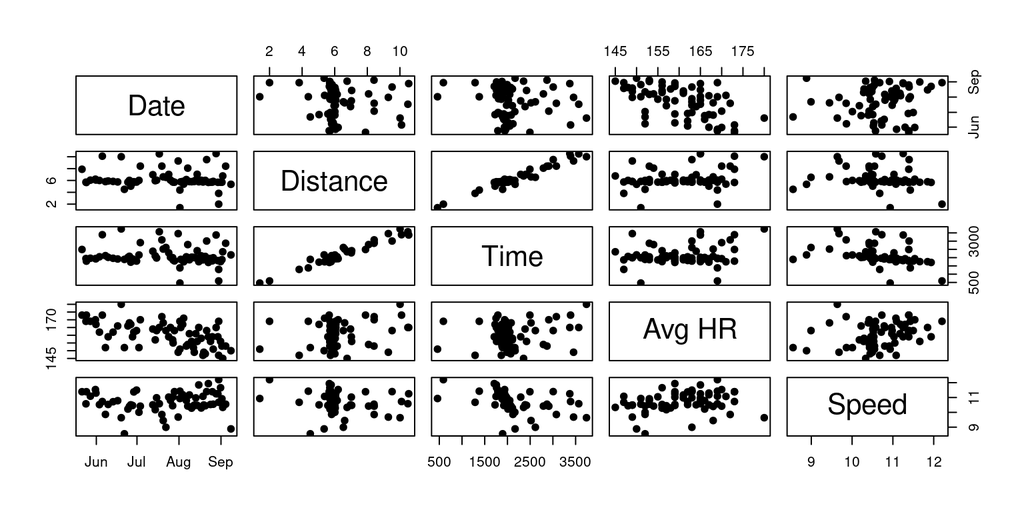

```r
pairs(garmin, pch = 20, cex = 1.5)
```

# garmin dataset - practical 2 - problem

1. Round distances for both datasets *kalenji* and *garmin* to integers.
2. Calculate average *Speed* per *Distance*.
3. (Full) join the tables returning *Distance*, *Time*, and *Average Speed* (km/h).

# garmin dataset - practical 2 - solution

```r
kalenji <- read_csv("kalenji.csv", show_col_types = FALSE) %>%
  mutate(Hours = hour(time) + minute(time) / 60 + second(time) / 3600,
         Speed = km / Hours) %>%
  transmute(Distance = km, Time = time, Speed)
```

# garmin dataset - practical 2 - solution

1. Round distances for both datasets *kalenji* and *garmin* to integers.
2. Calculate average *Speed* per *Distance*.
3. Join the tables returning *Distance*, *Time*, and *Average Speed* (km/h).

For each dataset: `round() %>% summarize() %>% join()`.

# garmin dataset - practical 2 - solution

1. Round distances for both datasets *kalenji* and *garmin* to integers.
2. Calculate average *Speed* per *Distance*.
3. Join the tables returning *Distance*, *Time*, and *Average Speed* (km/h).

For each dataset: `round() %>% summarize() %>% join()`.

However, one `round() %>% summarize()` can be nested into `join()`:

```r
left_table %>%
  round() %>%
  summarize() %>%
  join(
    right_table() %>%
      round() %>%
      summarize()
  )
```

# garmin dataset - practical 2 - solution

1. Round distances for both datasets *kalenji* and *garmin* to integers.
2. Calculate average *Speed* per *Distance*.
3. Join the tables returning *Distance*, *Time*, and *Average Speed* (km/h).

```r
avg_speed <- kalenji %>%
  mutate(Distance = round(Distance)) %>%
  group_by(Distance) %>%
  summarize(`Average Speed` = mean(Speed)) %>%
  full_join(
    garmin %>%
      mutate(Distance = round(Distance)) %>%
      group_by(Distance) %>%
      summarize(`Average Speed` = mean(Speed)),
    by = "Distance",
    suffix = c(" - kalenji", " - garmin")
  )
```

**Line indentations (should) matter**

# garmin dataset - practical 2 - solution

1. Round distances for both datasets *kalenji* and *garmin* to integers.
2. Calculate average *Speed* per *Distance*.
3. Join the tables returning *Distance*, *Time*, and *Average Speed* (km/h).

```r
avg_speed
```

```
## # A tibble: 10 × 3
##   Distance `Average Speed - kalenji` `Average Speed - garmin`
##      <dbl>                     <dbl>                    <dbl>
## 1        5                      10.8                    10.2
## 2        6                      11.0                    10.9
## 3        8                      11.2                    10.5
## 4        9                      10.8                     9.68
## # … with 6 more rows
```

# garmin dataset - practical 2 - line indentations matter

```r
avg_speed <- kalenji %>%
  mutate(Distance = round(Distance)) %>%
  group_by(Distance) %>%
  summarize(`Average Speed` = mean(Speed)) %>%
  full_join(
    garmin %>%
      mutate(Distance = round(Distance)) %>%
      group_by(Distance) %>%
      summarize(`Average Speed` = mean(Speed)),
    by = "Distance",
    suffix = c(" - kalenji", " - garmin")
  )
```

# garmin dataset - practical 2 - no consistent indentations = you’re a monster

```r
avg_speed <- kalenji %>%
  mutate(Distance = round(Distance)) %>% group_by(Distance) %>%
  summarize(
    `Average Speed` = mean(Speed)) %>%
  full_join(garmin %>%
              mutate(Distance = round(Distance)) %>% group_by(Distance) %>%
              summarize(`Average Speed` = mean(Speed)), by = "Distance",
            suffix = c(
              " - kalenji",
              " - garmin"
            ))
```

# garmin dataset - practical 2 - how do you even write?

```
Nel mezzo
del
cammin di      nostra vita, mi
ritrovai perunaselvaoscura
che
la
diritta
via     era       smarrita.
```

# garmin dataset - practical 2 - writing and coding are not that different

```
Nel mezzo del cammin di nostra vita,
mi ritrovai per una selva oscura
che la diritta via era smarrita.
```

One line = one operation

One block = one coherent prodecure

lines -> blocks -> pipeline

# garmin dataset - practical 2 - considerations

1. Round distances for both datasets *kalenji* and *garmin* to integers.
2. Calculate average *Speed* per *Distance*.
3. Join the tables returning *Distance*, *Time*, and *Average Speed* (km/h).

All manipulations were done *on the fly*, i.e. without saving objects to memory unless specifically stated: `avg_speed <-` is the only new object. Old tables are still the same:

```r
garmin$Distance #not rounded
```

```
##  [1]  5.35  8.41  6.76  5.70  5.70  2.00  3.82  5.69 10.54  5.84  5.72  5.71
## [13]  5.67  9.52  6.01  5.81  5.74  6.03  5.78  7.04  6.06  5.83  5.84  5.79
## [25]  5.81  8.08  6.15  5.38  5.83  5.77  4.38  1.40  9.29  5.71  5.72  5.80
## [37]  6.07  7.02  6.53  6.61  8.42 10.49  6.04  5.96  6.97  8.42  6.01  5.73
## [49]  5.78  5.58  5.04  6.01  5.71  4.50 10.01  5.75  5.84  5.91  5.81 10.10
## [61]  6.00  6.07  6.21  6.05  5.66  5.71  7.89
```

# garmin dataset - practical 2 - more considerations

Let’s say we want to compare *Average Speed* between the two methods, e.g. `boxplot()`.

How would you manipulate this table?

```r
avg_speed
```

```
## # A tibble: 10 × 3
##   Distance `Average Speed - kalenji` `Average Speed - garmin`
##      <dbl>                     <dbl>                    <dbl>
## 1        5                      10.8                    10.2
## 2        6                      11.0                    10.9
## 3        8                      11.2                    10.5
## 4        9                      10.8                     9.68
## # … with 6 more rows
```

Tidy data: one row = one observation.

# tidyr

# tidyr - goal

Goal: To achieve **tidy** data.

Pros:

- Very powerful: few commands to achieve tidy data.
- Extremely versatile.

Cons:

- Syntax can be counter-intuitive.

# tidyr - pivotting

The most frequent use of *tidyr* is for *pivotting*: from long to wide and back again.

# tidyr - long and wide tables

The most frequent use of *tidyr* is for *pivotting*: from long to wide and back again.

**Long table**

```r
long <- tibble(
  Group = LETTERS[1:3],
  x = rnorm(3)
)
long
```

```
## # A tibble: 3 × 2
##   Group      x
##   <chr>  <dbl>
## 1 A     -0.418
## 2 B     -0.754
## 3 C     -0.222
```

**Wide table**

```r
wide <- tibble(
  A = rnorm(1),
  B = rnorm(1),
  C = rnorm(1)
)
wide
```

```
## # A tibble: 1 × 3
##        A     B     C
##    <dbl> <dbl> <dbl>
## 1 -0.613 -1.78  1.51
```

# tidyr - wide to long

`pivot_longer()`: wide to long.

```r
wide %>% pivot_longer(cols = everything(),
                      names_to = "Group",
                      values_to = "x")
```

```
## # A tibble: 3 × 2
##   Group      x
##   <chr>  <dbl>
## 1 A     -0.613
## 2 B     -1.78
## 3 C      1.51
```

# tidyr - wide to long and back again

`pivot_longer()`: wide to long.

```r
wide %>% pivot_longer(cols = everything(),
                      names_to = "Group",
                      values_to = "x")
```

```
## # A tibble: 3 × 2
##   Group      x
##   <chr>  <dbl>
## 1 A     -0.613
## 2 B     -1.78
## 3 C      1.51
```

`pivot_wider()`: long to wide.

```r
long %>% pivot_wider(names_from = Group,
                     values_from = x)
```

```
## # A tibble: 1 × 3
##        A      B      C
##    <dbl>  <dbl>  <dbl>
## 1 -0.418 -0.754 -0.222
```

# tidyr - practical - problem

```r
avg_speed
```

```
## # A tibble: 10 × 3
##   Distance `Average Speed - kalenji` `Average Speed - garmin`
##      <dbl>                     <dbl>                    <dbl>
## 1        5                      10.8                    10.2
## 2        6                      11.0                    10.9
## 3        8                      11.2                    10.5
## 4        9                      10.8                     9.68
## # … with 6 more rows
```

1. Make `avg_speed` table longer: three columns *Distance*, *Speed*, and *Method*.
2. *Method* should have values *kalenji* or *garmin* only.
3. Boxplot: *Speed ~ Method*.

# tidyr - practical - solution

1. Make `avg_speed` table longer: three columns *Distance*, *Speed*, and *Method*.

```r
avg_speed <- avg_speed %>%
  pivot_longer(cols = contains("Speed"),
               names_to = "Method",
               values_to = "Speed")
```

# tidyr - practical - solution

1. Make `avg_speed` table longer: three columns *Distance*, *Speed*, and *Method*.
2. *Method* should have values *kalenji* or *garmin* only.

```r
avg_speed <- avg_speed %>%
  mutate(Method = gsub("[[:alpha:]]+ [[:alpha:]]+ - ", "", Method))
```

# tidyr - practical - solution

1. Make `avg_speed` table longer: three columns *Distance*, *Speed*, and *Method*.
2. *Method* should have values *kalenji* or *garmin* only.
3. Boxplot: *Speed ~ Method*.

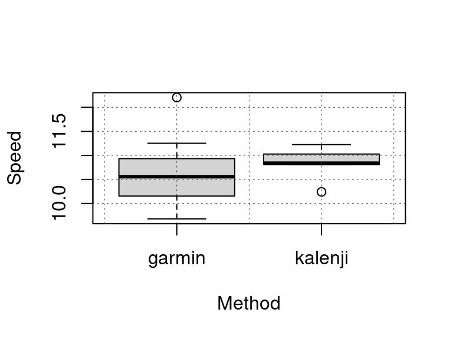

```r
boxplot(Speed ~ Method, data = avg_speed)
grid(col = "grey20", lwd = .5)
```

# tidyverse - final practical - problem

1. Plot total distance per week, coloring points according to sampling method.
2. Plot average speed per week, coloring points according to sampling method.

# tidyverse - final practical - solution

```r
d <- read_csv("kalenji.csv", show_col_types = FALSE) %>%
  mutate(date = as_date(date, format = "%m/%d/%y"),
         week = week(date),
         speed = km / ( hour(time) + minute(time) / 60 )) %>%
  group_by(week) %>%
  summarize(`Total km` = sum(km),
            `Avg speed` = mean(speed)) %>%
  mutate(method = "Kalenji") %>%
  bind_rows(
    read_csv("garmin.csv", show_col_types = FALSE) %>%
      filter(`Activity Type` == "Running") %>%
      mutate(Date = as_date(Date),
             week = week(Date),
             speed = Distance / ( hour(Time) + minute(Time) / 60 )) %>%
      group_by(week) %>%
      summarize(`Total km` = sum(Distance),
                `Avg speed` = mean(speed)) %>%
      mutate(method = "Garmin")
  ) %>%
  mutate(week = ifelse(week > 40, week - 53, week)) #these are last year weeks
```

# tidyverse - final practical - plot

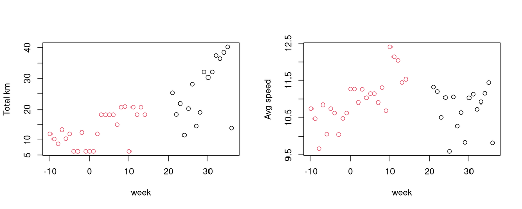

```r
par(mfrow = c(1, 2))
with(d, plot(week, `Total km`, col = as.factor(method)))
with(d, plot(week, `Avg speed`, col = as.factor(method)))
```

I probably wasn’t so accurate with the Kalenji watch.

# The end

[figure not shown]